[output not shown]

First, let us load the data and necessary packages:

```r
load("ames_train.Rdata")
library(MASS)
library(dplyr)
```

```r
library(ggplot2)
```

# 1

Make a labeled histogram (with 30 bins) of the ages of the houses in the data set, and describe the distribution.

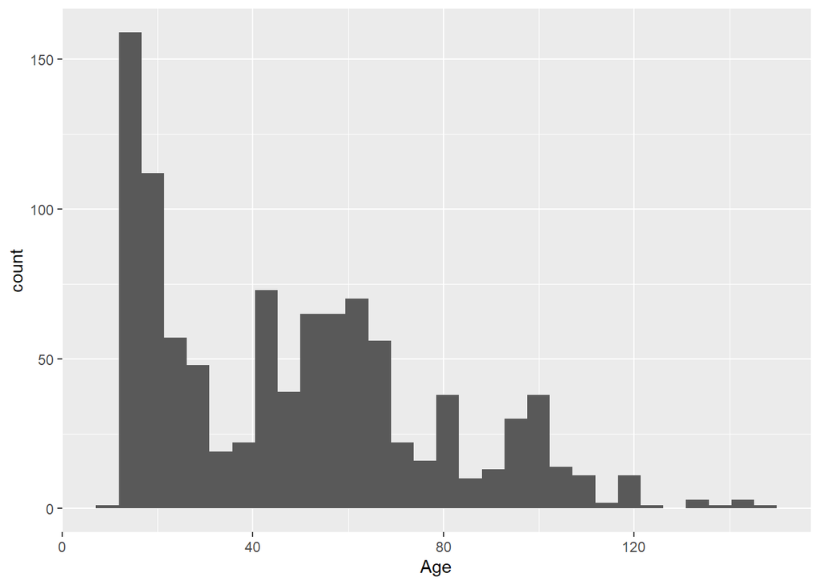

```r
ames_train <- ames_train %>%
        mutate(Age = 2021 - Year.Built)

ggplot(ames_train, aes(x = Age), labs(title = "Housing Age Distribution"))  +
  geom_histogram(bins = 30)
```

```r
summary(ames_train$Age)
```

```
##    Min. 1st Qu.  Median    Mean 3rd Qu.    Max.
##    11.0    20.0    46.0    48.8    66.0   149.0
```

The mean age of homes(48.8) is larger than the median age of 46.0. This positively skewed (Right-skewed) distribution of the Age feature is confirmed by the histogram.

A second peak indicates a boom in the 1960s.

# 2

The mantra in real estate is “Location, Location, Location!” Make a graphical display that relates a home price to its neighborhood in Ames, Iowa. Which summary statistics are most appropriate to use for determining the most expensive, least expensive, and most heterogeneous (having the most variation in housing price) neighborhoods? Report which neighborhoods these are based on the summary statistics of your choice. Report the value of your chosen summary statistics for these neighborhoods.

```r
ames_train %>%
  select(price, Neighborhood) %>%
  group_by(Neighborhood) %>%
  summarize(median = median(price), max = max(price), min = min(price), sd = sd(price)) %>%
  arrange(desc(median))
```

```
## # A tibble: 27 x 5
##    Neighborhood  median    max    min      sd
##    <fct>          <dbl>  <int>  <int>   <dbl>
##  1 StoneBr      340692. 591587 180000 123459.
##  2 NridgHt      336860  615000 173000 105089.
##  3 NoRidge      290000  405000 235000  35889.
##  4 GrnHill      280000  330000 230000  70711.
##  5 Timber       232500  425000 175000  84030.
##  6 Somerst      221650  468000 139000  65199.
##  7 Greens       212625  214000 155000  29063.
##  8 Veenker      205750  385000 150000  72545.
##  9 Crawfor      205000  392500  96500  71268.
## 10 CollgCr      195800  475000 110000  52786.
## # ... with 17 more rows
```

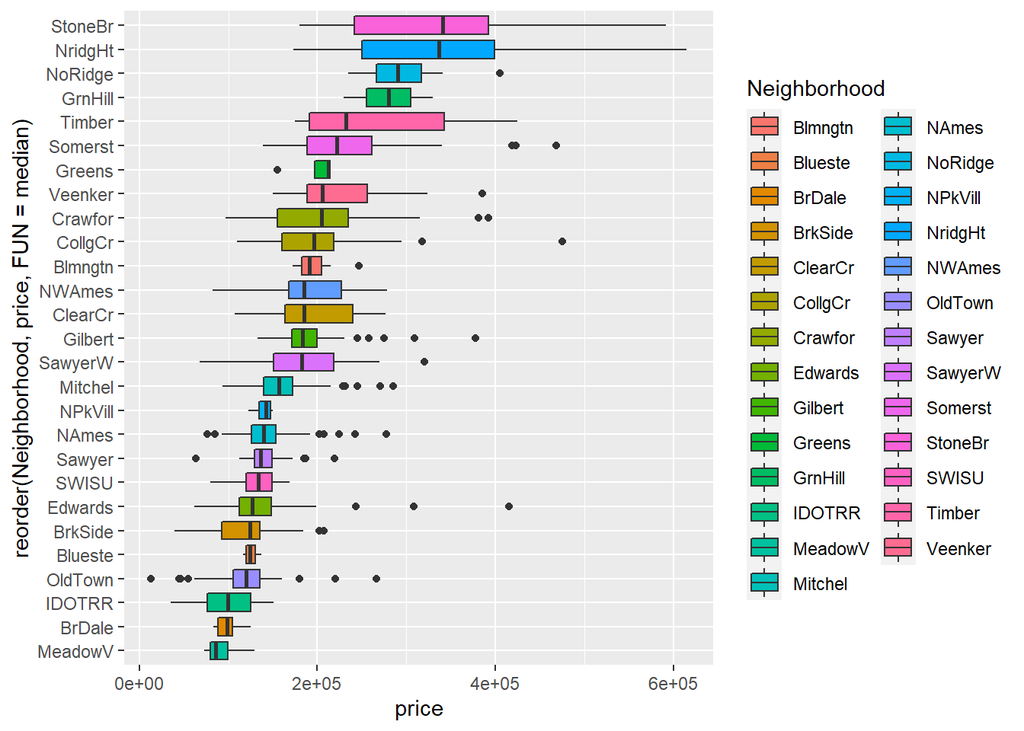

```r
ggplot(ames_train, aes(y = price, x = reorder(Neighborhood, price, FUN = median), fill = Neighborhood)) +
  geom_boxplot() +
  coord_flip()
```

Box plots best display the price variations of neighborhoods. I think it is easier to make observations by reversing the axes and fill by neighborhoods.

As the housing prices are positively skewed, median prices are the better estimate than the mean for making generalizations.

# 3

Which variable has the largest number of missing values? Explain why it makes sense that there are so many missing values for this variable.

```r
apply(ames_train, 2, function(x) sum(is.na(x))) %>% sort %>%
  tail()
```

```
## Lot.Frontage Fireplace.Qu        Fence        Alley Misc.Feature      Pool.QC
##          167          491          798          933          971          997
```

Pool.QC has the largest “NA” entries as “No Pool” is the NA value in the data and most homes do not have pools.

# 4

We want to predict the natural log of the home prices. Candidate explanatory variables are lot size in square feet (Lot.Area), slope of property (Land.Slope), original construction date (Year.Built), remodel date (Year.Remod.Add), and the number of bedrooms above grade (Bedroom.AbvGr). Pick a model selection or model averaging method covered in the Specialization, and describe how this method works. Then, use this method to find the best multiple regression model for predicting the natural log of the home prices.

```r
library(BAS)
log_lm = lm(log(price) ~ Lot.Area
            + Land.Slope
            + Year.Built
            + Year.Remod.Add
            +Bedroom.AbvGr,
            data = ames_train)

summary(log_lm)
```

```
##
## Call:
## lm(formula = log(price) ~ Lot.Area + Land.Slope + Year.Built +
##     Year.Remod.Add + Bedroom.AbvGr, data = ames_train)
##
## Residuals:
##     Min      1Q  Median      3Q     Max
## -2.0878 -0.1651 -0.0211  0.1657  0.9945
##
## Coefficients:
##                  Estimate Std. Error t value Pr(>|t|)
## (Intercept)    -1.371e+01  8.574e-01 -15.996  < 2e-16 ***
## Lot.Area        1.028e-05  1.106e-06   9.296  < 2e-16 ***
## Land.SlopeMod   1.384e-01  4.991e-02   2.773  0.00565 **
## Land.SlopeSev  -4.567e-01  1.514e-01  -3.016  0.00263 **
## Year.Built      6.049e-03  3.788e-04  15.968  < 2e-16 ***
## Year.Remod.Add  6.778e-03  5.468e-04  12.395  < 2e-16 ***
## Bedroom.AbvGr   8.686e-02  1.077e-02   8.063 2.12e-15 ***
## ---
## Signif. codes:  0 '***' 0.001 '**' 0.01 '*' 0.05 '.' 0.1 ' ' 1
##
## Residual standard error: 0.279 on 993 degrees of freedom
## Multiple R-squared:  0.5625, Adjusted R-squared:  0.5598
## F-statistic: 212.8 on 6 and 993 DF,  p-value: < 2.2e-16
```

```r
log_bic = bas.lm(log(price)~Lot.Area
                 + Land.Slope
                 + Year.Built
                 + Year.Remod.Add
                 +Bedroom.AbvGr,
                 data = ames_train,
        prior = "BIC",
        modelprior = uniform(),
        method = "MCMC" )

summary(log_bic)
```

```
##                P(B != 0 | Y)    model 1       model 2      model 3
## Intercept          1.0000000     1.0000     1.0000000     1.000000
## Lot.Area           0.9796875     1.0000     1.0000000     1.000000
## Land.SlopeMod      0.6054688     1.0000     0.0000000     1.000000
## Land.SlopeSev      0.7226562     1.0000     1.0000000     0.000000
## Year.Built         0.9968750     1.0000     1.0000000     1.000000
## Year.Remod.Add     0.9945312     1.0000     1.0000000     1.000000
## Bedroom.AbvGr      0.9804688     1.0000     1.0000000     1.000000
## BF                        NA     1.0000     0.6674353     0.330911
## PostProbs                 NA     0.4176     0.3044000     0.178800
## R2                        NA     0.5625     0.5591000     0.558500
## dim                       NA     7.0000     6.0000000     6.000000
## logmarg                   NA -2198.1673 -2198.5716571 -2199.273250
##                      model 4       model 5
## Intercept          1.0000000  1.000000e+00
## Lot.Area           1.0000000  0.000000e+00
## Land.SlopeMod      0.0000000  0.000000e+00
## Land.SlopeSev      0.0000000  0.000000e+00
## Year.Built         1.0000000  1.000000e+00
## Year.Remod.Add     1.0000000  1.000000e+00
## Bedroom.AbvGr      1.0000000  0.000000e+00
## BF                 0.1061955  3.125949e-35
## PostProbs          0.0757000  1.010000e-02
## R2                 0.5544000  4.728000e-01
## dim                5.0000000  3.000000e+00
## logmarg        -2200.4098178 -2.277618e+03
```

The best model is evaluated using Bayesian Model Averaging (BMA).

BIC is selected as a prior distribution because it provides the highest Posterior Probabilities values. The model recommends to keep all of the selected variables as the best fitted predictors of the home price through BMA (BIC and MCMC). The linear model seems to infer concurrence with BMA.

# 5

Which home has the largest squared residual in the previous analysis (Question 4)? Looking at all the variables in the data set, can you explain why this home stands out from the rest (what factors contribute to the high squared residual and why are those factors relevant)?

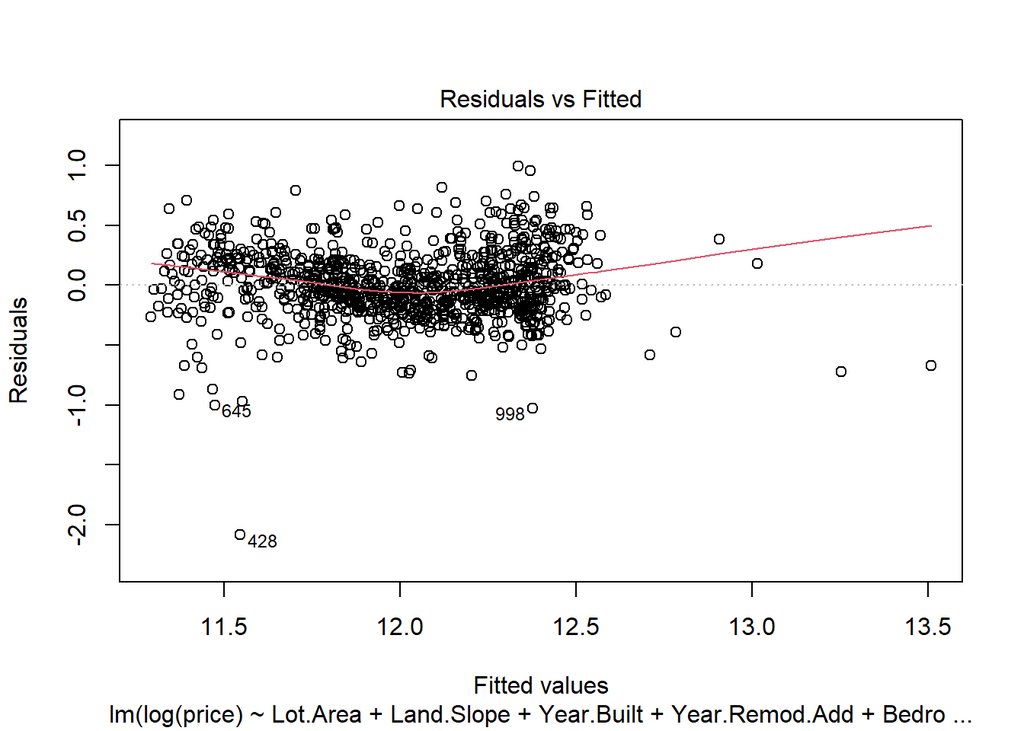

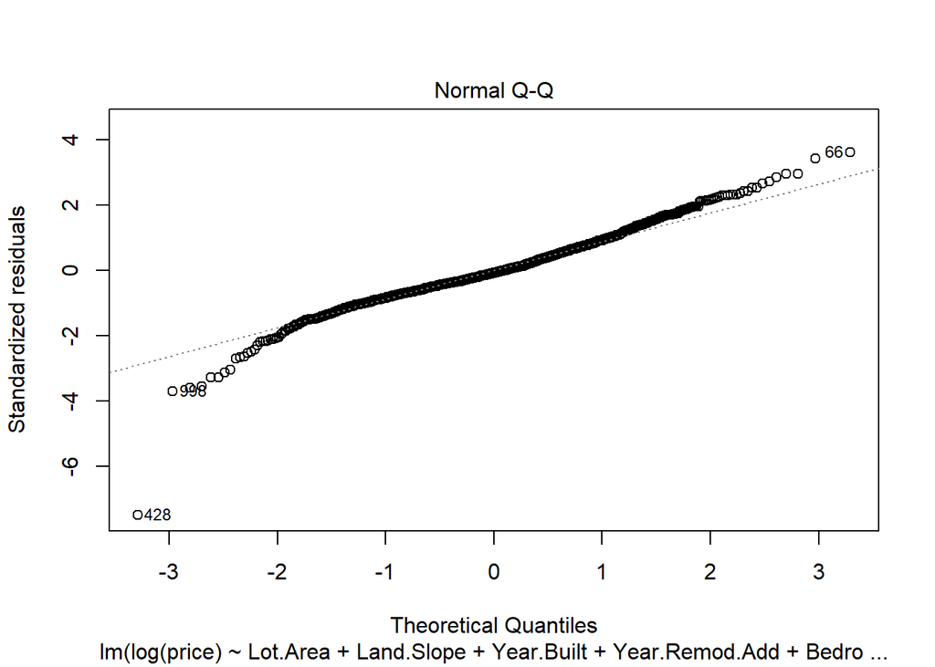

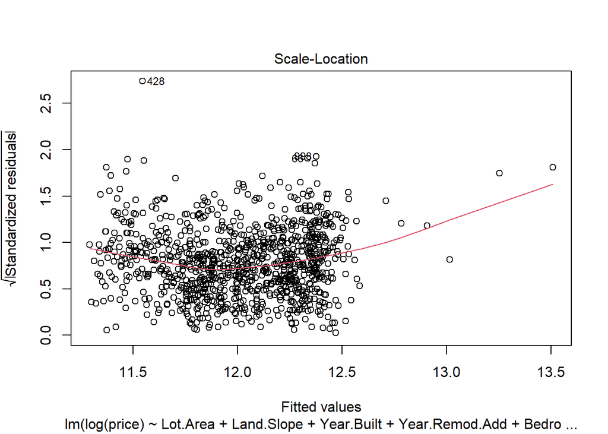

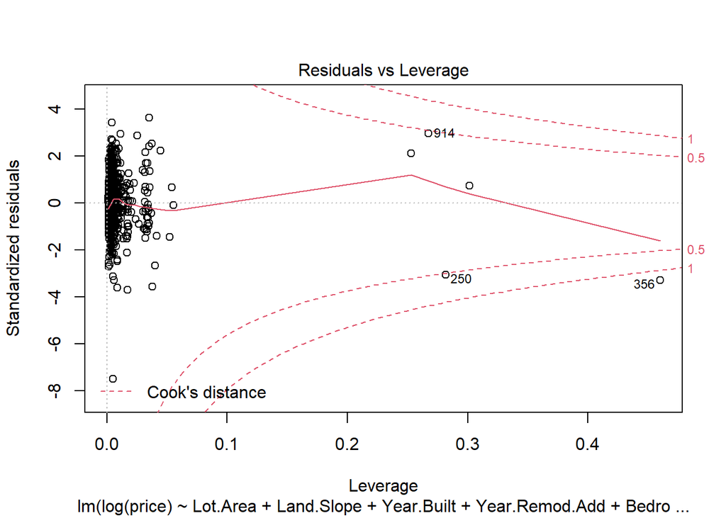

```r
plot(log_lm)
```

```r
House <- ames_train[which(log_lm$residuals^2 == max((log_lm$residuals)^2)),]

House
```

```
## # A tibble: 1 x 82
##         PID  area price MS.SubClass MS.Zoning Lot.Frontage Lot.Area Street Alley
##       <int> <int> <int>       <int> <fct>            <int>    <int> <fct>  <fct>
## 1 902207130   832 12789          30 RM                  68     9656 Pave   <NA>
## # ... with 73 more variables: Lot.Shape <fct>, Land.Contour <fct>,
## #   Utilities <fct>, Lot.Config <fct>, Land.Slope <fct>, Neighborhood <fct>,
## #   Condition.1 <fct>, Condition.2 <fct>, Bldg.Type <fct>, House.Style <fct>,
## #   Overall.Qual <int>, Overall.Cond <int>, Year.Built <int>,
## #   Year.Remod.Add <int>, Roof.Style <fct>, Roof.Matl <fct>,
## #   Exterior.1st <fct>, Exterior.2nd <fct>, Mas.Vnr.Type <fct>,
## #   Mas.Vnr.Area <int>, Exter.Qual <fct>, Exter.Cond <fct>, ...
```

```r
predPrice <- exp(log_lm$fitted.values[which(log_lm$residuals^2 == max((log_lm$residuals)^2))])

predPrice
```

```
##      428
## 103176.2
```

Lot PID number 902207130 is the outlier with highest squared residual when running plot residuals vs fitted.

The house was sold for ~ $12,000 in 1928. The predicted price is ~ $103176 which makes it a significant outlier.